# Can We Trust Russian Public Opinion Surveys?

A Data-Driven Investigation

Noah M. Buckley

June 2026 (reboot: new pollster-convergence, framing, and salience analyses; data through 2026)

# Can We Trust Russian Public Opinion Surveys?

## A Data-Driven Investigation

*Noah M. Buckley*

### Key findings

> 1. **Support is real, but shallow — and how shallow depends on the question you ask.** Most Russians who say they support the war *also* say Russia should start peace talks (68%). But force a choice — negotiations *or* continued fighting — and most supporters pick fighting; only ~30% choose peace. Almost none (19%) would undo the decision to start the war. Roughly **3% are consistent hawks.** “Shallow” and “real” are both true, depending on wording.
> 2. **The instrument is sound.** Five independent measurements — state phone (VTsIOM), independent face-to-face (Levada), academic online (PROPA), a second state firm (FOM) — trace the *same* approval trajectory from 2018 to 2026. VTsIOM’s published headline numbers match the raw microdata we compute ourselves (r = 0.995), agreeing even on month-to-month *changes* (r = 0.95).
> 3. **Conformism and disengagement, not fear.** Asked open-ended what they noticed last week, ~38% of Russians say “nothing” and under 10% volunteer politics at all. The people who duck the approval question look like *disapprovers*, not silent supporters. The war rally was mostly conversion (former disapprovers becoming approvers), not opposition falling silent.
> 4. **Even if you doubt the levels, the changes still talk.** Social-desirability bias shifts the *level* of measured support but largely cancels in *first differences* — which is what most credible research on Russian opinion actually uses.

> *Social-desirability bias is real — list experiments bound it at roughly 6–10 points, and interviewer-rated candor shows a genuine openness gradient. The argument here is not that the surveys are perfect. It is that dismissing them is worse than using them carefully.*

## 1. Introduction: The Question That Won’t Go Away

Every few months, a new poll lands on social media showing that 70-something percent of Russians support the war in Ukraine — or approve of Vladimir Putin — and the arguments start again. The skeptics say the numbers are meaningless: people are terrified, pollsters are complicit, the whole enterprise is a sham. The defenders say the numbers are roughly right: imperfect, yes, but comparable to polling anywhere. A smaller, quieter group says the numbers are real but misleading: majority “support” hides a shallow, fragile conformism that could evaporate under the right conditions.

Who’s right? And how would we know?

This piece tries to answer that question with data, not assertion. I’ve spent the better part of a decade working with Russian survey data, and I’ll be honest about my priors: I think the surveys are more reliable than their critics claim. But I want to test that belief, not just assert it. I’ll lay out the strongest arguments on every side, derive testable predictions from each, and then look at what the data actually shows. Where the data refuses to cooperate with my priors — as it does, in a couple of places below — I say so.

This is a guided tour through the evidence, with code and an interactive simulator you can play with.

## 2. The Debate: Three Positions

### 2a. “The surveys work fine” (The Levada defense)

- Response rates are stable and comparable to Western surveys
- Self-selection experiment shows no bias
- List experiments bound SDB at ~10pp
- Cross-pollster convergence

### 2b. “The surveys are useless” (The skeptical position)

- 550,000+ fines, 1,000+ imprisonments for anti-war speech
- Private phone conversations prosecuted (Vedel case)
- Fieldwork quality is terrible (anonymous insiders)
- Self-selection is unfalsifiable

### 2c. “The surveys capture something real, but not what you think” (The middle ground)

- “Two majorities”: only 16-22% are consistent supporters
- “Defensive consolidation” ≠ genuine rally
- DK is anomalously high on war questions
- Headline numbers overstate depth of conviction

## 3. The Fundamental Tension

There’s a deep tension between two characterizations of Russian society that are both widely held, sometimes by the same people:

**View A: Russians are afraid to speak.** The state is so repressive that ordinary citizens won’t even tell an anonymous pollster what they really think. Support is performative. The surveys capture fear, not opinion.

**View B: Russians don’t want to think about it.** Most people aren’t terrified — they’re disengaged. They don’t follow the war closely, they avoid uncomfortable information, many don’t even know about the “discrediting the armed forces” law, and they’d rather give a quick answer and get back to their lives. What the surveys capture is *real conformism and disengagement*, not fabricated loyalty.

These views can’t both be fully true. If people are paralyzed by fear, they should be hyper-aware of what’s happening and carefully managing their responses. If they’re disengaged and unaware, there’s nothing to be afraid of.

### What the law actually says

- “Discrediting the armed forces” targets *public* statements, not survey responses
- No documented case of prosecution for a survey response — ever
- But: the Vedel case (prosecution based on wiretapped private calls) is genuinely chilling
- Key question: Do ordinary Russians even know the specifics? Alyukov’s research suggests most practice “motivated avoidance” — they don’t *want* to know

## 4. What Would We Expect to See?

### If fear dominates (View A):

1. DK/refusal rates should spike after Feb 2022 and after each repressive escalation
2. Sample composition should shift (regime critics drop out)
3. Responses should be *very stable* (everyone giving the “right” answer)
4. Mobilization, Prigozhin, Kursk shouldn’t produce dips (the “right” answer doesn’t change)
5. There should be almost zero disapproval in the data
6. F2F surveys should show *more* support than telephone (interviewer presence amplifies fear)

### If disengagement dominates (View B):

1. DK rates should be high on political questions, normal on personal/economic ones
2. Responses should fluctuate with events (shallow support is labile)
3. Shocks like mobilization should produce real dips, followed by gradual recovery
4. Some disapproval should be present (the disengaged aren’t all terrified)
5. Mode effects should be modest (disengagement doesn’t depend on interview format)

### If surveys are fabricated (Extreme nihilist):

1. Data should show implausible statistical properties (digit patterns, response vector diversity)
2. Levada and VTsIOM should diverge on demographic correlates
3. Data should not respond meaningfully to real-world events
4. Cross-wave correlation structure should be suspiciously consistent

[We test these predictions in Appendix C. Spoiler: the data passes every test we throw at it.]

## 5. The Data

This piece draws on a harmonized archive of Russian survey microdata (about 5.3 million respondents, 1992–2026) plus several behavioral and published-aggregate sources:

- **Levada Courier** (1992–2020 microdata): Monthly face-to-face surveys, ~1,600/wave. The independent workhorse. (Wartime Levada exists as published aggregates; we recover it two ways below.)
- **VTsIOM Sputnik** (2018–2024): Daily telephone surveys, ~1,600/day. 3.3 million observations. Unmatched temporal resolution.
- **Published toplines** (VTsIOM + FOM, 1990–2026): The pollsters’ own weekly headline approval/trust numbers. Extends the picture past Sputnik, to May 2026, and lets us check published figures against microdata.
- **War Surveys** (2022–Feb 2026): Five organizations (Russian Field, Chronicles, Levada, VTsIOM, FOM), five methodologies, overlapping question batteries. The natural experiment in survey design; Russian Field now runs through a February 2026 peace-deal wave.
- **PROPA** (2024–2025): A five-wave academic *online* panel (Helsinki / Zavadskaya et al.) — independent, non-governmental, lowest-SDB mode — covering the post-Sputnik gap.
- **“Weekremember”** (VTsIOM Express, 2011–2017): An open-ended “what did you notice last week?” battery — unprompted salience.
- **Yandex Wordstat**: What Russians actually search for online. External behavioral validation.

### Who are the respondents? Sample composition over time

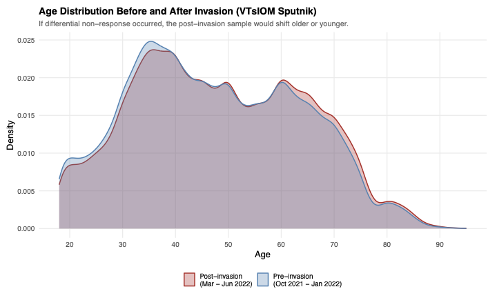

Figure 13a. Age distribution of respondents: pre- vs post-Feb 2022 (VTsIOM Sputnik).

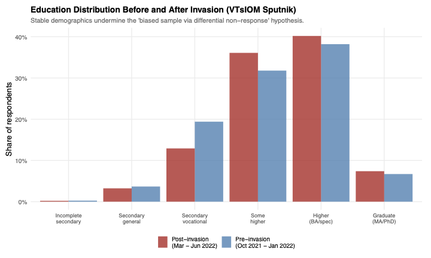

Figure 13b. Education distribution: pre- vs post-Feb 2022 (VTsIOM Sputnik).

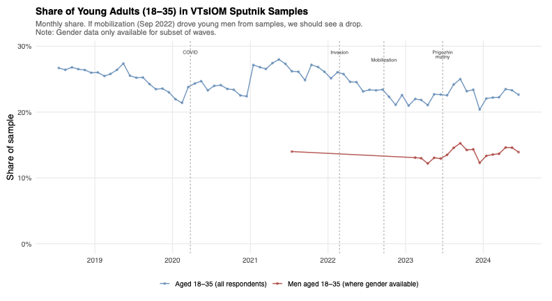

Figure 14. Share of young adults (18-35) over time (VTsIOM Sputnik).

## 6. Item Non-Response: The Dog That Didn’t Bark (Or Did It?)

### 6a. DK rates on war vs non-political questions

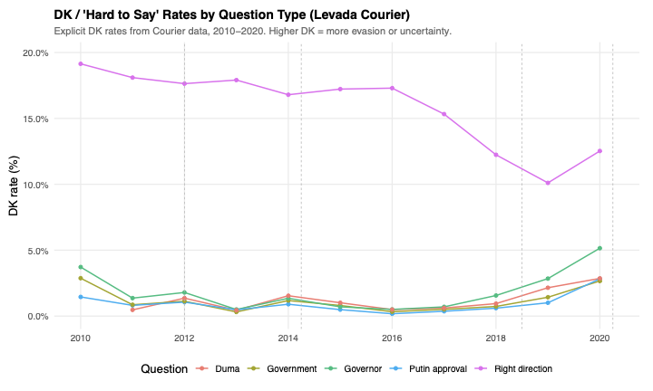

Figure 6. DK/refusal rates by question type and period.

### 6b. Who are the DK respondents?

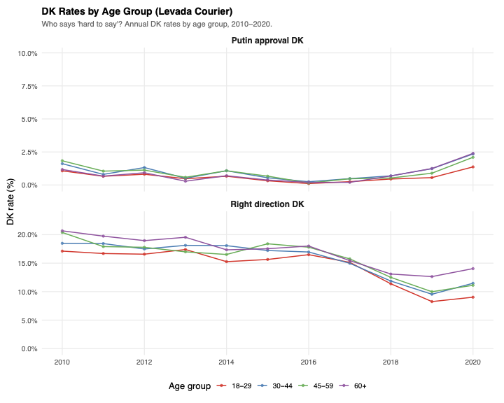

### 6c. DK over time: event responsiveness

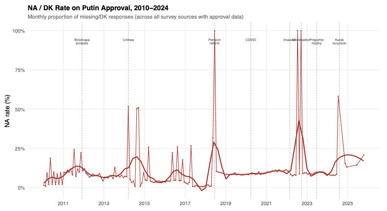

Figure 4. NA/refusal rate time series across surveys (2010-2024).

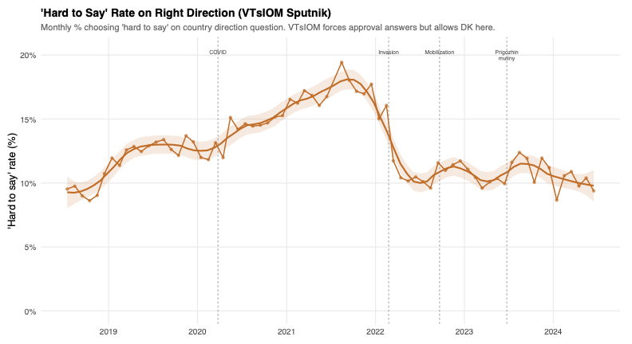

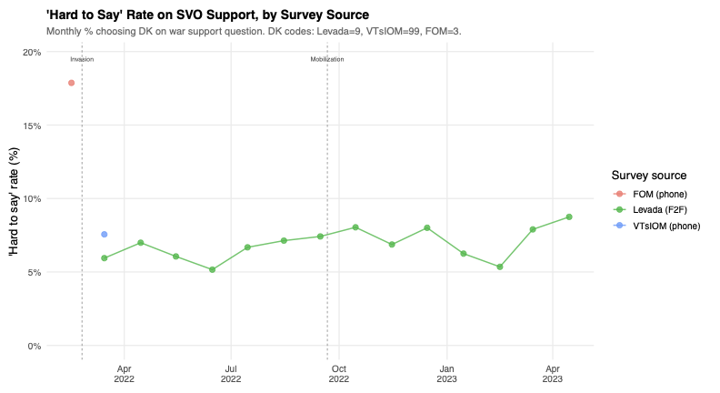

Figure 8. DK rates on war support by survey source.

A more direct test of the fear hypothesis: if respondents are silently strategic about which questions they answer, DK should be elevated specifically on the *politically sensitive* items relative to safer ones. We have the data to look. The DK extraction in `dk_all.Rdata` (4.28M obs across nine surveys) lets us compare DK rates across question types within the same respondent.

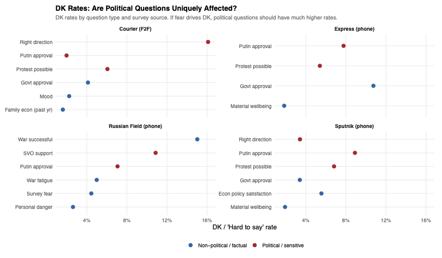

Figure 43. DK rates by question sensitivity (political vs economic vs personal), 2018-2024.

The demographic profile of DK respondents reinforces the disengagement reading. They look like disapprovers, not like silent supporters:

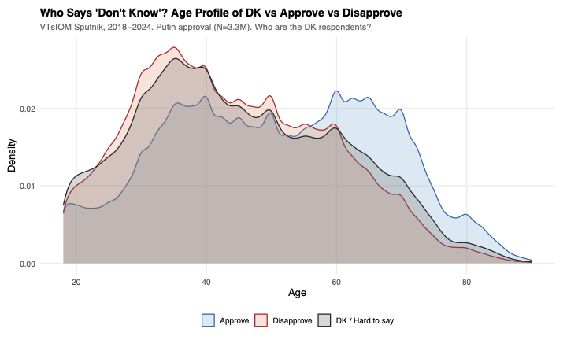

Figure 42a. Age density of DK respondents vs approve / disapprove respondents.

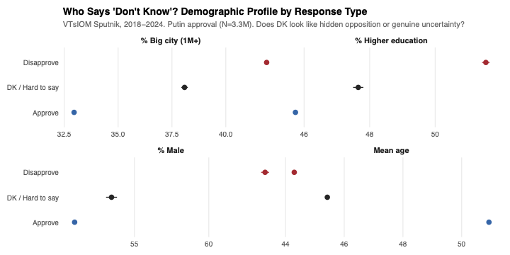

Figure 42b. Demographics of DK respondents: age (years), share male, share in big cities.

DK respondents are younger (mean age 45 vs 51 for approvers), more male (53% vs 51%), and more urban (39% in big cities vs 34%). On a fear story, the typical DK respondent should be older, more rural, more loyalist — people who’d be most embarrassed to voice disapproval to a state-affiliated interviewer. We see the opposite: the demographic of DK looks like the demographic of disapproval. Combined with the rally anatomy in Section 7a½ — where DK was roughly flat (slightly negative) at the invasion while disapproval *fell* by 18 points — the data point to former disapprovers becoming approvers, not falling silent.

### 6c½. DK and approval: an inverse relationship

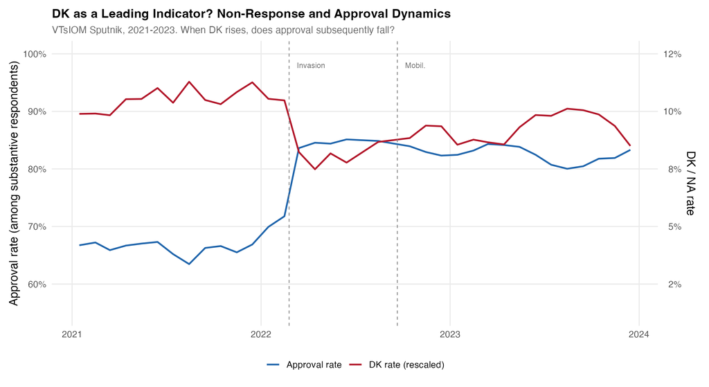

Figure 40. DK as a leading indicator? Non-response and approval dynamics (VTsIOM Sputnik, 2021–2023).

DK and approval are strongly inversely correlated (r = −0.82) in the Sputnik data. Before the war, DK ran around 10–11% and approval around 65–67%. At the invasion, DK plunged to ~8% while approval surged. This is consistent with a “rallying” dynamic where uncertain people are temporarily pushed off the fence — not into silence, but into expressing support. After mobilization, DK partially recovers as the initial rally effect fades.

The formal leading-indicator test (does a DK change in month *t* predict an approval change in *t+1*?) is inconclusive — the contemporaneous relationship dominates.

### 6d. What do respondents themselves say about fear?

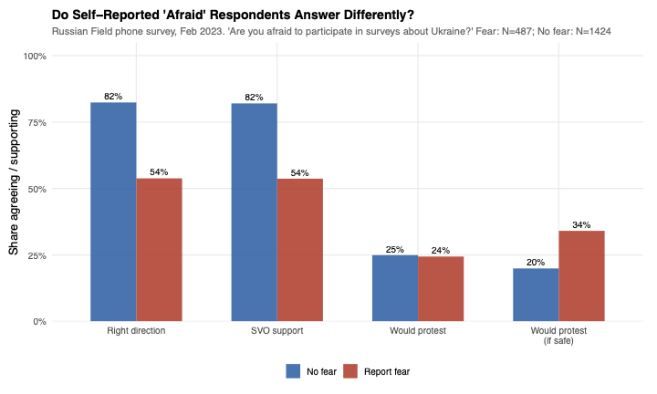

Figure 29. Survey fear cross-tab: do ‘afraid’ respondents answer differently? (Russian Field, Feb 2023).

Chronicles’ online survey (July 2022) offers a complementary angle: fear of private discussion vs. fear of speaking out publicly.

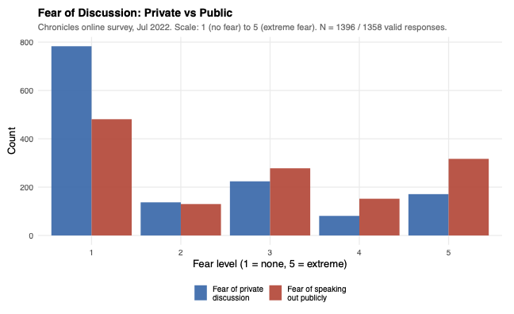

Figure 29b. Fear of private vs public discussion (Chronicles online survey, Jul 2022).

People are substantially more afraid of speaking out publicly (mean 2.77 on a 1-5 scale) than of private discussion (mean 2.08). This supports the Levada position: fear is about *public expression*, not private opinion. A survey is closer to private discussion than public speech, which suggests surveys are capturing attitudes closer to genuine ones.

### 6e. The Afina experiment: what interviewers see

The Afina/Bessudnov survey (February 28–March 1, 2022 — days five and six of the invasion) offers the most direct window into SDB we have. After each interview, the interviewer rated the respondent’s openness on a three-point scale: “closed and spoke with apprehension” (8%), “quite open” (67%), or “very frank and eager” (25%).

This was an independent multi-agency telephone survey with 1,642 completed interviews from 27,751 contact attempts — a 5.9% completion rate, comparable to Russian Field’s RDD surveys.

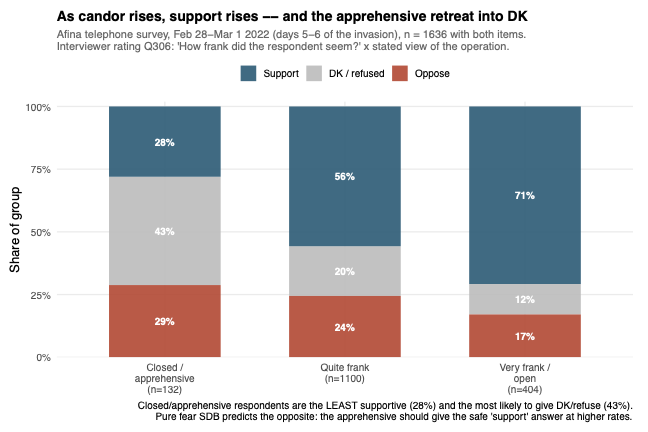

Figure 34. War-attitude breakdown by interviewer-assessed openness (Afina, Feb 28–Mar 1, 2022, N = 1,636).

The gradient is dramatic, and its *shape* is the interesting part. As the interviewer’s rating moves from “closed and apprehensive” (8% of the sample) to “very frank and open” (25%), stated support climbs from **28% to 71%**. But look at where the apprehensive respondents go: they are not piling into the safe “support” answer. They split roughly evenly between supporting (28%), opposing (29%), and — most of all — giving don’t-know or refusing (43%). The frank respondents, by contrast, give DK only 12% of the time.

This rules out the simplest fear story. If apprehensive respondents were *lying upward* to stay safe, they should show the *highest* support, not the lowest. Instead, discomfort shows up as **silence, not false loyalty.** Two readings survive:

1. **Self-selection on enthusiasm.** People who are genuinely pro-war are also happy to talk about it; people with mixed or negative views are naturally more guarded. The interviewer is partly detecting *comfort with the topic*, which is correlated with — but not the same as — true opinion.
2. **Discomfort-driven non-response.** A milder version of the fear story: some uneasy respondents don’t fabricate support, they retreat to “hard to say.” This inflates the *apparent* support rate among answerers by removing reluctant skeptics from the denominator, but it does not manufacture enthusiasm.

Both are probably partly true, and both imply real bias. Even the most open quarter of the sample reaches only 71% support — below the ~80% VTsIOM reported the same week — and the apprehensive eighth is split. Weighting the groups, the data is consistent with true early-war support in the **50–60% range, with measurement adding perhaps 10–15 points** to the headline. That is larger than the list-experiment bound (~6–10pp) but far short of the skeptics’ claims. (This is also the single piece of evidence in the piece that points *most* toward sizable bias; I flag it rather than bury it.)

## 7. Do the Surveys Respond to Reality?

### 7a. The narrative arc of Putin approval

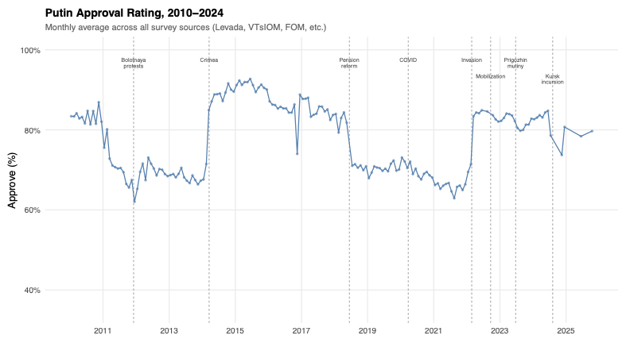

Figure 1. Putin approval 2010-2024, all survey sources.

### 7a½. Anatomy of the war rally

Where did the “new approvers” come from? The stacked area chart below decomposes all Sputnik respondents into three groups — approve, disapprove, and DK/no answer — showing their shares of the total sample over time.

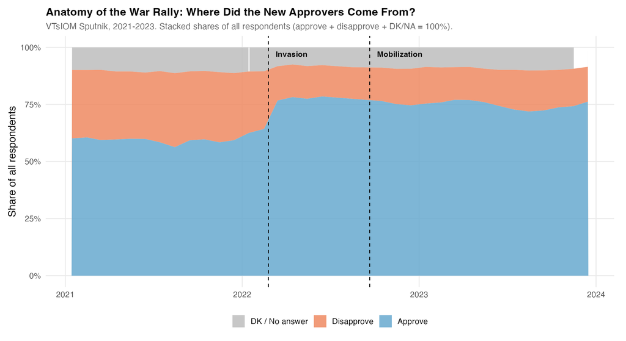

Figure 39. Rally anatomy: where did the new approvers come from? (VTsIOM Sputnik, 2021–2023).

These are shares of ALL respondents, including DK. The standard “approval rate” (approve / (approve + disapprove)) jumps somewhat more because excluding the small DK shift from the denominator.

The implication is the *reverse* of the original “silent dissenter” story. The rally was largely a conversion event: many former disapprovers became approvers. Only a small share went silent. That is a different and arguably stronger finding for interpreting wartime surveys — the rally signal is real, not an artifact of opposition dropping out.

### 7b–7c. The mobilization stress test, Prigozhin, and Kursk

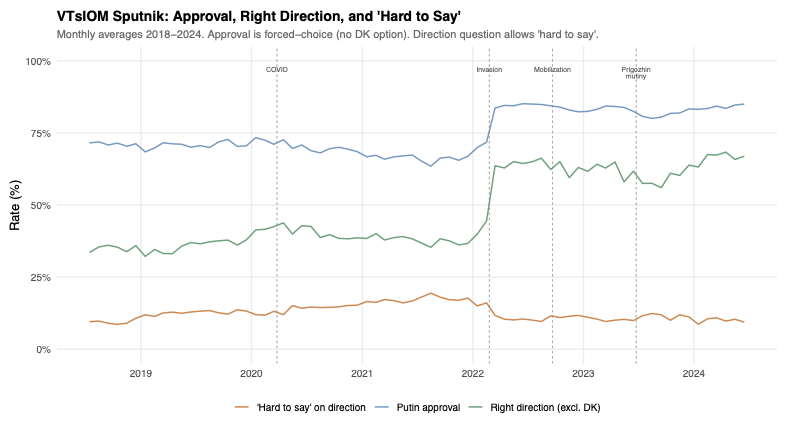

VTsIOM’s daily telephone polls of ~1,600 respondents give us approximately 600,000 observations per year — far more statistical power than any monthly survey. Even small dips of 1–2 percentage points are detectable.

### 7d. What fear would predict vs what we see

If fear dominated, these events — which didn’t change the “correct” answer — shouldn’t move the needle. They do.

### 7e. The mobilization stress test by age

If the data is real, the mobilization announcement should hit hardest among draft-eligible young adults (18–35). They face direct personal risk; older respondents don’t. This is a sharp prediction that fabricated data would not produce.

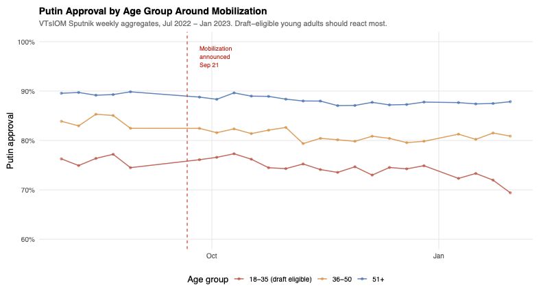

Figure 31. Putin approval by age group around mobilization (VTsIOM Sputnik, weekly, Jul 2022 – Jan 2023).

The data confirms the prediction. The 18–35 group shows the most sustained decline after mobilization, dropping from ~77% to ~70% over the following months. The 51+ group barely moves. This age-differentiated response requires real sampling of different demographic groups reacting to a real event in predictable ways.

### 7f. Protest potential: a sensitive question answered honestly

VTsIOM Sputnik asks two sensitive questions in every wave: “Are mass protests likely in your locality?” and “Would you personally join?” These are asked of 3 million respondents across 2018–2024.

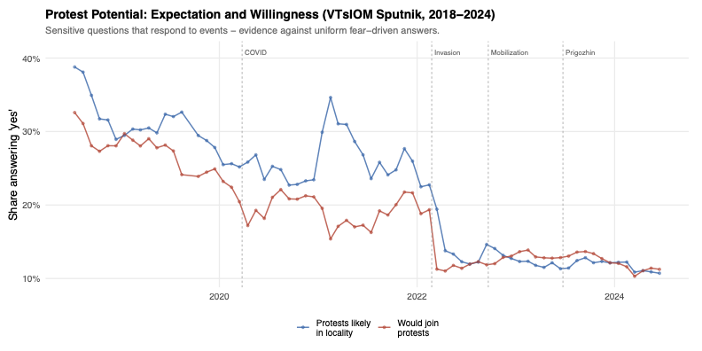

Figure 32. Protest potential over time (VTsIOM Sputnik, 2018-2024, N = 3M).

Both series respond to events in expected ways: protest expectation spiked during the pension reform backlash (2018–2019), dropped during COVID, and collapsed further after the invasion. If fear suppressed honest answers uniformly, these lines should be flat near zero. Instead, they show a meaningful dynamic that tracks the political environment. The gradual decline is itself informative: it likely reflects both genuine demobilization and growing caution — but the fact that 10–12% still say they’d join protests during wartime suggests the instrument isn’t completely fear-frozen.

### 7g. Economic questions as placebo

Non-political economic questions provide a “placebo test” for the survey instrument. If the same survey that asks about Putin approval also captures genuine economic sentiment, it strengthens trust in the instrument as a whole.

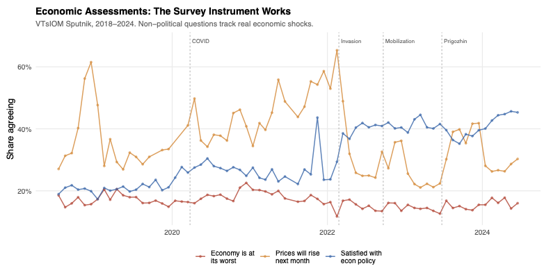

Figure 33. Economic assessments over time (VTsIOM Sputnik, 2018-2024).

Inflation expectations spiked during COVID and again at the invasion (consistent with ruble crash and sanctions). Satisfaction with economic policy shows a patriotic bump at invasion then gradually stabilizes. “Economy at its worst” remains relatively low throughout — most respondents don’t think conditions are dire. These series track real economic events: the survey instrument is clearly picking up genuine variation on less sensitive questions, which increases confidence it’s doing the same on more sensitive ones.

## 7h. Even if you doubt levels, changes still talk

Even if SDB shifts the level of measured support upward, the *changes* are harder to fake. Social desirability bias that is roughly constant over time cancels out in first differences. If approval drops 5 points after mobilization in both the “true” and “measured” series, the drop is real — regardless of whether the level is 65% or 75%.

This matters because most serious research on Russian public opinion doesn’t rely on headline approval numbers. It uses variation — across time, across regions, across demographic groups. Difference-in-differences, event studies, panel models: these all exploit *changes*, not levels. And changes are robust to constant or slowly-varying SDB.

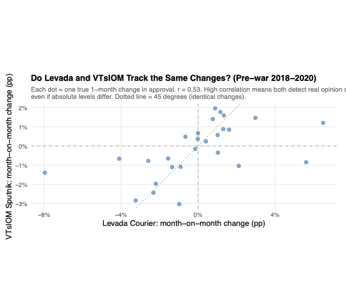

Figure 17. Month-on-month changes: Levada vs VTsIOM (correlation scatter).

**The caveat:** Not a silver bullet. Shocks that simultaneously change both true attitudes and SDB intensity — like the war itself, which created both a genuine rally and a new legal environment for speech — violate this assumption. But for events *within* the wartime period (mobilization, Prigozhin, Kursk), the SDB regime is roughly stable.

The Fake Russia Generator confirms this in simulation: even with 12 percentage points of SDB, the correlation between true and measured month-on-month changes remains above 0.86. And we get the same lesson from real data in Section 8f, where VTsIOM’s published approval and the raw microdata differ in *level* by a constant ~7 points yet agree on month-to-month *changes* at r = 0.95. Changes are robust to bias.

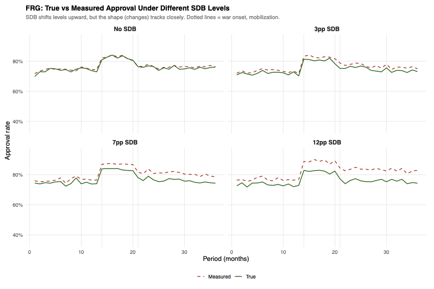

Figure 19a. FRG: True vs measured approval under four SDB levels.

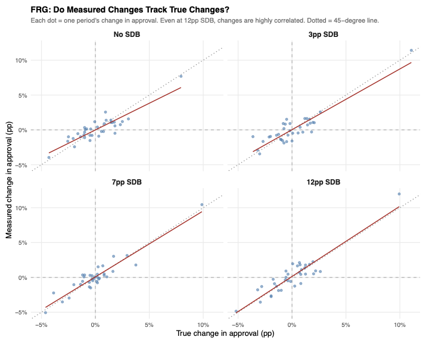

Figure 19b. FRG: Do measured changes track true changes? Scatter by SDB level.

### 7h½. The strongest version of the changes argument: within-person panel data

The “constant SDB cancels out” logic above runs at the *aggregate* level: we average the bias over many respondents and assume it shifts together. A more demanding version of the same test asks: do *individual* respondents’ approval changes track *their own* changing circumstances?

PROPA — a 5-wave online panel run by University of Helsinki researchers from March 2024 through October 2025 — lets us run this test. The panel is academic, non-Russian-government, and online (so any “interviewer fear” channel is at its weakest). We use the published fuzzy-match panel ID (region + sex + birth year ± 1) to follow 1,321 panelists across waves and look at within-person change.

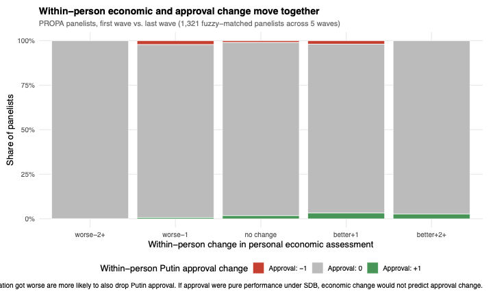

Figure 47. PROPA panel: within-person economic and approval change move together (1,321 fuzzy-matched panelists, first wave vs. last wave).

The within-person correlation between change in personal economic assessment and change in Putin approval is positive but modest (r = 0.04 across 758 valid first-vs-last pairs). Mean approval change is **+1.6 percentage points** for panelists whose economic situation improved versus **−1.2 points** for those whose situation worsened. The signal is small because most panelists *don’t* change approval across the panel window — support is sticky — but the direction is what disengagement predicts and what fear does not. Pure performative support should be uncorrelated with own economic experience; instead the relationship is what you would expect of people answering honestly about their material lives and updating their political attitudes accordingly.

This is also the cleanest test we have of the panel-data version of the changes-vs-levels argument: SDB that is constant within a respondent across waves drops out entirely in first differences. Whatever signal survives is genuine.

### 7i. The open-ended test: what Russians notice on their own

Every test so far asks a *pointed* question and worries about what people will say. There is a way to sidestep that: ask nothing pointed at all. For six years (2011–2017) VTsIOM’s weekly “Express” survey asked an open-ended question with no prompts and no answer options — *what events of the past week did you notice or find important?* — and recorded whatever respondents volunteered. What people bring up unbidden is the closest thing we have to unforced salience, and it cuts two ways for the trust question.

First, it responds to reality, sharply. The share spontaneously mentioning each topic is locked to real events:

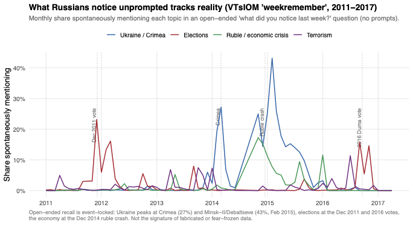

Figure 56. Spontaneous mentions track events: Ukraine peaks at Crimea and Minsk-II, elections at the Dec 2011 and 2016 votes, the economy at the 2014 ruble crash (VTsIOM ‘weekremember’, 2011-2017).

Unprompted Ukraine mentions go from near zero to 27% at the annexation of Crimea (and 43% during the Debaltseve/Minsk-II crisis of February 2015); election mentions spike at the December 2011 and 2016 votes; the economy surfaces exactly at the December 2014 ruble crash. A fabricated or fear-frozen instrument cannot produce event-locked *spontaneous* recall — the fabricator would have to anticipate which events people would volunteer, and when.

Second, and more revealing for the “don’t want to think about it” thesis: when nobody hands them a topic, most Russians do not volunteer politics at all.

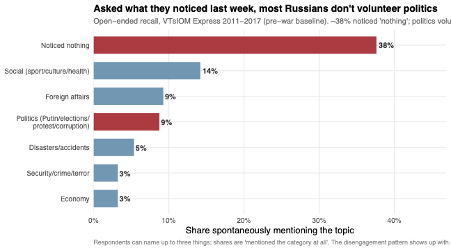

Figure 56b. Asked what they noticed last week, ~38% of Russians say ‘nothing’ and under 10% volunteer politics (VTsIOM Express, 2011-2017, pre-war baseline).

## 8. Levada vs VTsIOM: The Unlikely Validation

### 8a. Level comparison

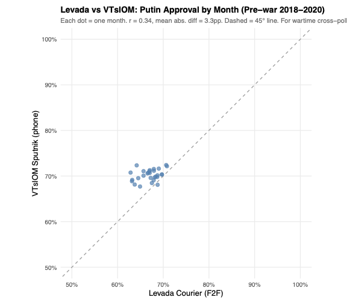

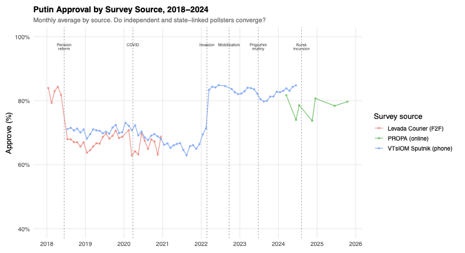

### 8c. Same demographic gradients?

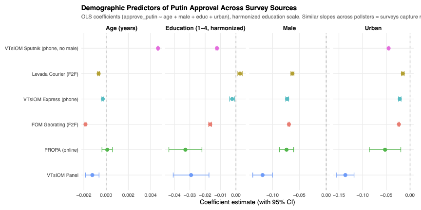

Figure 15. Cross-pollster coefficient comparison: same regression, different survey sources.

### 8d. What this means

If the government’s own pollster (VTsIOM) produces data with the same demographic structure and event-responsiveness as the “independent” pollster (Levada), the most parsimonious explanation is that both are measuring something real.